# **Problem Statement**

1. Customer segmentation and Developing a recommendation system to suggest top-selling products to customers within each segment

# **Objectives**

1. Data Cleaning & Transformation
2. Feature Engineering : Develop new features based on the transactional data to create a customer-centric dataset
3. Data Preprocessing
4. Customer Segmentation using K-Means Clustering
5. Cluster Analysis , RFM calculation
6. Recommendation System

# **Dataset**

1. The Dataset obtained from UCL Machine Learning
2. It covers all transactions between the period 2010 ,2011.

# **Tools and Technologies**

1. NumPy
2. Pandas
3. Seaborn
4. Matplotlib

# **Algorithms**

1. Isolation Forest
2. StandardScaler
3. Principal Component Analysis
4. K-means
5. Linear Regression

```python
import numpy as np
import pandas as pd
import seaborn as sns
import matplotlib.pyplot as plt
import matplotlib.gridspec as gridspec
from sklearn.ensemble import IsolationForest
from sklearn.preprocessing import StandardScaler
from sklearn.decomposition import PCA
from sklearn.cluster import KMeans
from scipy.stats import linregress
from yellowbrick.cluster import KElbowVisualizer, SilhouetteVisualizer
from sklearn.metrics import silhouette_score, calinski_harabasz_score, davies_bouldin_score
from collections import Counter
```

```python
df = pd.read_csv('/content/drive/MyDrive/Luminar/onlineretail_dataset.csv') #Read dataset
```

```python
df.head()
```

|  | InvoiceNo | StockCode | Description | Quantity | InvoiceDate | UnitPrice | CustomerID | Country |
| --- | --- | --- | --- | --- | --- | --- | --- | --- |
| 0 | 536365 | 85123A | WHITE HANGING HEART T-LIGHT HOLDER | 6 | 12/1/2010 8:26 | 2.55 | 17850.0 | United Kingdom |
| 1 | 536365 | 71053 | WHITE METAL LANTERN | 6 | 12/1/2010 8:26 | 3.39 | 17850.0 | United Kingdom |
| 2 | 536365 | 84406B | CREAM CUPID HEARTS COAT HANGER | 8 | 12/1/2010 8:26 | 2.75 | 17850.0 | United Kingdom |
| 3 | 536365 | 84029G | KNITTED UNION FLAG HOT WATER BOTTLE | 6 | 12/1/2010 8:26 | 3.39 | 17850.0 | United Kingdom |
| 4 | 536365 | 84029E | RED WOOLLY HOTTIE WHITE HEART. | 6 | 12/1/2010 8:26 | 3.39 | 17850.0 | United Kingdom |

```python
df.info()
```

```
<class 'pandas.core.frame.DataFrame'>
RangeIndex: 541909 entries, 0 to 541908
Data columns (total 8 columns):
 #   Column       Non-Null Count   Dtype
---  ------       --------------   -----
 0   InvoiceNo    541909 non-null  object
 1   StockCode    541909 non-null  object
 2   Description  540455 non-null  object
 3   Quantity     541909 non-null  int64
 4   InvoiceDate  541909 non-null  object
 5   UnitPrice    541909 non-null  float64
 6   CustomerID   406829 non-null  float64
 7   Country      541909 non-null  object
dtypes: float64(2), int64(1), object(5)
memory usage: 33.1+ MB
```

```python
df.describe() #summary statistics
```

|  | Quantity | UnitPrice | CustomerID |
| --- | --- | --- | --- |
| count | 541909.000000 | 541909.000000 | 406829.000000 |
| mean | 9.552250 | 4.611114 | 15287.690570 |
| std | 218.081158 | 96.759853 | 1713.600303 |
| min | -80995.000000 | -11062.060000 | 12346.000000 |
| 25% | 1.000000 | 1.250000 | 13953.000000 |
| 50% | 3.000000 | 2.080000 | 15152.000000 |
| 75% | 10.000000 | 4.130000 | 16791.000000 |
| max | 80995.000000 | 38970.000000 | 18287.000000 |

```python
df.isna().sum()
```

```
InvoiceNo           0
StockCode           0
Description      1454
Quantity            0
InvoiceDate         0
UnitPrice           0
CustomerID     135080
Country             0
dtype: int64
```

# Preprocessing

```python
df = df.dropna(subset=['CustomerID', 'Description'])
```

```python
df.isnull().sum()
```

```
InvoiceNo      0
StockCode      0
Description    0
Quantity       0
InvoiceDate    0
UnitPrice      0
CustomerID     0
Country        0
dtype: int64
```

```python
df.duplicated().sum()
```

```
5225
```

```python
df.drop_duplicates(inplace=True) #Removing duplicates
```

```python
df.shape
```

```
(401604, 8)
```

```python
# invoice number with a "C" prefix or indicator, it likely signifies that the invoice is related to a credit transaction or cancelled transaction
def has_letters(invoice_no):
    return any(char.isalpha() for char in invoice_no)

# Filter for invoices with letters
df_with_letters = df[df['InvoiceNo'].apply(has_letters)]


df_with_letters
```

|  | InvoiceNo | StockCode | Description | Quantity | InvoiceDate | UnitPrice | CustomerID | Country |
| --- | --- | --- | --- | --- | --- | --- | --- | --- |
| 141 | C536379 | D | Discount | -1 | 12/1/2010 9:41 | 27.50 | 14527.0 | United Kingdom |
| 154 | C536383 | 35004C | SET OF 3 COLOURED FLYING DUCKS | -1 | 12/1/2010 9:49 | 4.65 | 15311.0 | United Kingdom |
| 235 | C536391 | 22556 | PLASTERS IN TIN CIRCUS PARADE | -12 | 12/1/2010 10:24 | 1.65 | 17548.0 | United Kingdom |
| 236 | C536391 | 21984 | PACK OF 12 PINK PAISLEY TISSUES | -24 | 12/1/2010 10:24 | 0.29 | 17548.0 | United Kingdom |
| 237 | C536391 | 21983 | PACK OF 12 BLUE PAISLEY TISSUES | -24 | 12/1/2010 10:24 | 0.29 | 17548.0 | United Kingdom |
| ... | ... | ... | ... | ... | ... | ... | ... | ... |
| 540449 | C581490 | 23144 | ZINC T-LIGHT HOLDER STARS SMALL | -11 | 12/9/2011 9:57 | 0.83 | 14397.0 | United Kingdom |
| 541541 | C581499 | M | Manual | -1 | 12/9/2011 10:28 | 224.69 | 15498.0 | United Kingdom |
| 541715 | C581568 | 21258 | VICTORIAN SEWING BOX LARGE | -5 | 12/9/2011 11:57 | 10.95 | 15311.0 | United Kingdom |
| 541716 | C581569 | 84978 | HANGING HEART JAR T-LIGHT HOLDER | -1 | 12/9/2011 11:58 | 1.25 | 17315.0 | United Kingdom |
| 541717 | C581569 | 20979 | 36 PENCILS TUBE RED RETROSPOT | -5 | 12/9/2011 11:58 | 1.25 | 17315.0 | United Kingdom |

8872 rows × 8 columns

```python
df_with_letters.describe()
```

|  | Quantity | UnitPrice | CustomerID |
| --- | --- | --- | --- |
| count | 8872.000000 | 8872.000000 | 8872.000000 |
| mean | -30.774910 | 18.899512 | 14990.152953 |
| std | 1172.249902 | 445.190864 | 1708.230387 |
| min | -80995.000000 | 0.010000 | 12346.000000 |
| 25% | -6.000000 | 1.450000 | 13505.000000 |
| 50% | -2.000000 | 2.950000 | 14868.000000 |
| 75% | -1.000000 | 4.950000 | 16393.000000 |
| max | -1.000000 | 38970.000000 | 18282.000000 |

```python
# Filter out the rows with InvoiceNo starting with "C" and create a new column indicating the transaction status
df['Transaction_Status'] = np.where(df['InvoiceNo'].astype(str).str.startswith('C'), 'Cancelled', 'Completed')
```

```python
df.sample(3)
```

|  | InvoiceNo | StockCode | Description | Quantity | InvoiceDate | UnitPrice | CustomerID | Country | Transaction_Status |
| --- | --- | --- | --- | --- | --- | --- | --- | --- | --- |
| 68903 | 541880 | 22355 | CHARLOTTE BAG SUKI DESIGN | 20 | 1/24/2011 10:38 | 0.85 | 13819.0 | United Kingdom | Completed |
| 414499 | 572461 | 23017 | APOTHECARY MEASURING JAR | 2 | 10/24/2011 12:56 | 12.50 | 17344.0 | United Kingdom | Completed |
| 64764 | 541670 | 22426 | ENAMEL WASH BOWL CREAM | 16 | 1/20/2011 12:34 | 2.95 | 14911.0 | EIRE | Completed |

```python
df.shape
```

```
(401604, 9)
```

```python
df['Transaction_Status'].value_counts()
```

```
Transaction_Status
Completed    392732
Cancelled      8872
Name: count, dtype: int64
```

```python
cancelled_transactions = df[df['Transaction_Status'] == 'Cancelled']
completed_transactions = df[df['Transaction_Status'] == 'Completed']
```

```python
cancelled_transactions.describe().drop('CustomerID', axis=1)
```

|  | Quantity | UnitPrice |
| --- | --- | --- |
| count | 8872.000000 | 8872.000000 |
| mean | -30.774910 | 18.899512 |
| std | 1172.249902 | 445.190864 |
| min | -80995.000000 | 0.010000 |
| 25% | -6.000000 | 1.450000 |
| 50% | -2.000000 | 2.950000 |
| 75% | -1.000000 | 4.950000 |
| max | -1.000000 | 38970.000000 |

```python
# Finding the percentage of cancelled transactions
cancelled_percentage = (cancelled_transactions.shape[0] / df.shape[0]) * 100
cancelled_percentage
```

```
2.209141343213713
```

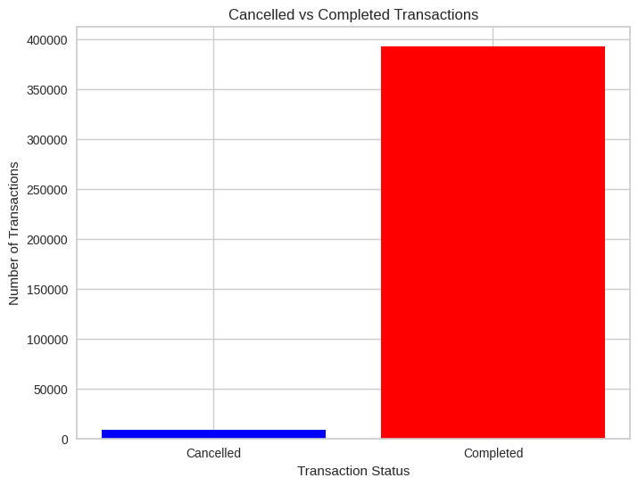

```python
status_labels = ['Cancelled', 'Completed']
status_counts = [cancelled_transactions.shape[0], completed_transactions.shape[0]]

plt.figure(figsize=(8, 6))
plt.bar(status_labels, status_counts, color=['blue', 'red'])
plt.xlabel('Transaction Status')
plt.ylabel('Number of Transactions')
plt.title('Cancelled vs Completed Transactions')
plt.show()
```

```python
# Finding the number of unique stock codes
unique_stock_codes = df['StockCode'].nunique()
unique_stock_codes
```

```
3684
```

```python
# Finding the top 10 most frequent stock codes
top_10_stocks = df['StockCode'].value_counts(normalize=True).head(10) * 100
top_10_stocks
```

```
StockCode
85123A    0.514188
22423     0.471609
85099B    0.413093
47566     0.350843
84879     0.349847
20725     0.335156
22720     0.304778
POST      0.297806
22197     0.276392
23203     0.275894
Name: proportion, dtype: float64
```

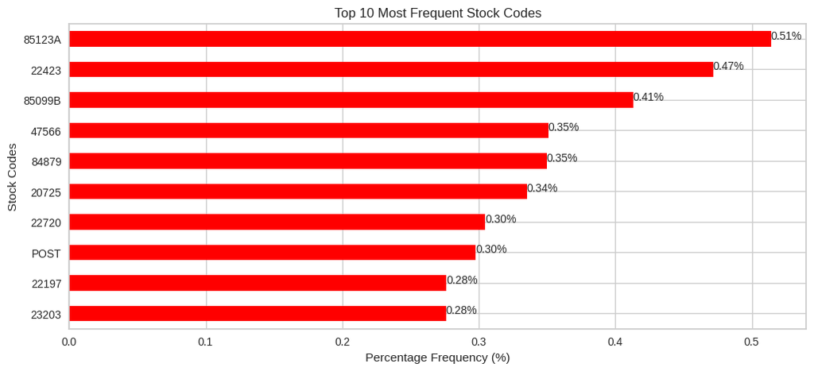

```python
# Plotting the top 10 most frequent stock codes
plt.figure(figsize=(12, 5))
top_10_stocks.plot(kind='barh', color='red')

# Adding the percentage frequency on the bars
for index, value in enumerate(top_10_stocks):
    plt.text(value, index, f'{value:.2f}%', fontsize=10)

plt.title('Top 10 Most Frequent Stock Codes')
plt.xlabel('Percentage Frequency (%)')
plt.ylabel('Stock Codes')
plt.gca().invert_yaxis()
plt.show()
```

```python
#Detect Anomiliew is stockcode
# Finding the number of numeric characters in each unique stock code
unique_stock_codes = df['StockCode'].unique()
unique_stock_codes
```

```
array(['85123A', '71053', '84406B', ..., '90214Z', '90089', '23843'],
      dtype=object)
```

```python
type(unique_stock_codes)
```

```
numpy.ndarray
```

```python
numeric_char_counts_in_unique_codes = pd.Series(unique_stock_codes).apply(lambda x: sum(c.isdigit() for c in str(x))).value_counts()
numeric_char_counts_in_unique_codes
```

```
5    3676
0       7
1       1
Name: count, dtype: int64
```

```python
anomalous_stock_codes = numeric_char_counts_in_unique_codes.index[numeric_char_counts_in_unique_codes < 2]
```

```python
# Removing rows with anomalous stock codes from the dataset
df = df[~df['StockCode'].isin(anomalous_stock_codes)]
```

```python
df.shape
```

```
(401604, 9)
```

```python
df['UnitPrice'].describe()
```

```
count    401604.000000
mean          3.474064
std          69.764035
min           0.000000
25%           1.250000
50%           1.950000
75%           3.750000
max       38970.000000
Name: UnitPrice, dtype: float64
```

```python
df[df['UnitPrice']==0].describe()[['Quantity']]
```

|  | Quantity |
| --- | --- |
| count | 40.000000 |
| mean | 347.100000 |
| std | 1978.311813 |
| min | 1.000000 |
| 25% | 1.000000 |
| 50% | 4.500000 |
| 75% | 24.000000 |
| max | 12540.000000 |

```python
# Removing records with a unit price of zero to avoid potential data entry errors
df = df[df['UnitPrice'] > 0]
```

```python
df = df[df['Quantity'] > 0]
```

```python
# Resetting the index of the cleaned dataset
df.reset_index(drop=True, inplace=True)
```

```python
# Getting the number of rows in the dataframe
df.shape
```

```
(392692, 9)
```

```python
df['InvoiceDate']
```

```
0          12/1/2010 8:26
1          12/1/2010 8:26
2          12/1/2010 8:26
3          12/1/2010 8:26
4          12/1/2010 8:26
               ...
392687    12/9/2011 12:50
392688    12/9/2011 12:50
392689    12/9/2011 12:50
392690    12/9/2011 12:50
392691    12/9/2011 12:50
Name: InvoiceDate, Length: 392692, dtype: object
```

```python
# Convert InvoiceDate to datetime type
df['InvoiceDate'] = pd.to_datetime(df['InvoiceDate'])
df['InvoiceDay'] = df['InvoiceDate'].dt.date
```

```python
df['CustomerID'].value_counts()
```

```
CustomerID
17841.0    7676
14911.0    5670
14096.0    5111
12748.0    4412
14606.0    2677
           ...
16765.0       1
13302.0       1
13270.0       1
16148.0       1
17846.0       1
Name: count, Length: 4338, dtype: int64
```

```python
# Find the most recent purchase date for each customer
customer_data = df.groupby('CustomerID')['InvoiceDay'].max().reset_index()
```

```python
customer_data
```

|  | CustomerID | InvoiceDay |
| --- | --- | --- |
| 0 | 12346.0 | 2011-01-18 |
| 1 | 12347.0 | 2011-12-07 |
| 2 | 12348.0 | 2011-09-25 |
| 3 | 12349.0 | 2011-11-21 |
| 4 | 12350.0 | 2011-02-02 |
| ... | ... | ... |
| 4333 | 18280.0 | 2011-03-07 |
| 4334 | 18281.0 | 2011-06-12 |
| 4335 | 18282.0 | 2011-12-02 |
| 4336 | 18283.0 | 2011-12-06 |
| 4337 | 18287.0 | 2011-10-28 |

4338 rows × 2 columns

```python
# Find the most recent date in the entire dataset
most_recent_date = df['InvoiceDay'].max()
```

```python
most_recent_date
```

```
datetime.date(2011, 12, 9)
```

```python
# Convert InvoiceDay to datetime type before subtraction
customer_data['InvoiceDay'] = pd.to_datetime(customer_data['InvoiceDay'])
most_recent_date = pd.to_datetime(most_recent_date)

# Calculate the number of days since the last purchase for each customer
customer_data['Days_Since_Last_Purchase'] = (most_recent_date - customer_data['InvoiceDay']).dt.days

# Remove the InvoiceDay column
customer_data.drop(columns=['InvoiceDay'], inplace=True)
```

```python
customer_data.head()
```

|  | CustomerID | Days_Since_Last_Purchase |
| --- | --- | --- |
| 0 | 12346.0 | 325 |
| 1 | 12347.0 | 2 |
| 2 | 12348.0 | 75 |
| 3 | 12349.0 | 18 |
| 4 | 12350.0 | 310 |

```python
# Calculate the total number of transactions made by each customer
total_transactions = df.groupby('CustomerID')['InvoiceNo'].nunique().reset_index()
total_transactions
```

|  | CustomerID | InvoiceNo |
| --- | --- | --- |
| 0 | 12346.0 | 1 |
| 1 | 12347.0 | 7 |
| 2 | 12348.0 | 4 |
| 3 | 12349.0 | 1 |
| 4 | 12350.0 | 1 |
| ... | ... | ... |
| 4333 | 18280.0 | 1 |
| 4334 | 18281.0 | 1 |
| 4335 | 18282.0 | 2 |
| 4336 | 18283.0 | 16 |
| 4337 | 18287.0 | 3 |

4338 rows × 2 columns

```python
total_transactions.rename(columns={'InvoiceNo': 'Total_Transactions'}, inplace=True)
```

```python
total_transactions
```

|  | CustomerID | Total_Transactions |
| --- | --- | --- |
| 0 | 12346.0 | 1 |
| 1 | 12347.0 | 7 |
| 2 | 12348.0 | 4 |
| 3 | 12349.0 | 1 |
| 4 | 12350.0 | 1 |
| ... | ... | ... |
| 4333 | 18280.0 | 1 |
| 4334 | 18281.0 | 1 |
| 4335 | 18282.0 | 2 |
| 4336 | 18283.0 | 16 |
| 4337 | 18287.0 | 3 |

4338 rows × 2 columns

```python
# Calculate the total number of products purchased by each customer
total_products_purchased = df.groupby('CustomerID')['Quantity'].sum().reset_index()
total_products_purchased.rename(columns={'Quantity': 'Total_Products_Purchased'}, inplace=True)
total_products_purchased
```

|  | CustomerID | Total_Products_Purchased |
| --- | --- | --- |
| 0 | 12346.0 | 74215 |
| 1 | 12347.0 | 2458 |
| 2 | 12348.0 | 2341 |
| 3 | 12349.0 | 631 |
| 4 | 12350.0 | 197 |
| ... | ... | ... |
| 4333 | 18280.0 | 45 |
| 4334 | 18281.0 | 54 |
| 4335 | 18282.0 | 103 |
| 4336 | 18283.0 | 1357 |
| 4337 | 18287.0 | 1586 |

4338 rows × 2 columns

```python
# Merge the new features into the customer_data dataframe
customer_data = pd.merge(customer_data, total_transactions, on='CustomerID')
customer_data = pd.merge(customer_data, total_products_purchased, on='CustomerID')
```

```python
customer_data.head()
```

|  | CustomerID | Days_Since_Last_Purchase | Total_Transactions | Total_Products_Purchased |
| --- | --- | --- | --- | --- |
| 0 | 12346.0 | 325 | 1 | 74215 |
| 1 | 12347.0 | 2 | 7 | 2458 |
| 2 | 12348.0 | 75 | 4 | 2341 |
| 3 | 12349.0 | 18 | 1 | 631 |
| 4 | 12350.0 | 310 | 1 | 197 |

```python
# Calculate the total spend by each customer
df['Total_Spend'] = df['UnitPrice'] * df['Quantity']
total_spend = df.groupby('CustomerID')['Total_Spend'].sum().reset_index()
```

```python
total_spend
```

|  | CustomerID | Total_Spend |
| --- | --- | --- |
| 0 | 12346.0 | 77183.60 |
| 1 | 12347.0 | 4310.00 |
| 2 | 12348.0 | 1797.24 |
| 3 | 12349.0 | 1757.55 |
| 4 | 12350.0 | 334.40 |
| ... | ... | ... |
| 4333 | 18280.0 | 180.60 |
| 4334 | 18281.0 | 80.82 |
| 4335 | 18282.0 | 178.05 |
| 4336 | 18283.0 | 2045.53 |
| 4337 | 18287.0 | 1837.28 |

4338 rows × 2 columns

```python
# Calculate the average transaction value for each customer
average_transaction_value = total_spend.merge(total_transactions, on='CustomerID')
average_transaction_value['Average_Transaction_Value'] = average_transaction_value['Total_Spend'] / average_transaction_value['Total_Transactions']
```

```python
average_transaction_value
```

|  | CustomerID | Total_Spend | Total_Transactions | Average_Transaction_Value |
| --- | --- | --- | --- | --- |
| 0 | 12346.0 | 77183.60 | 1 | 77183.600000 |
| 1 | 12347.0 | 4310.00 | 7 | 615.714286 |
| 2 | 12348.0 | 1797.24 | 4 | 449.310000 |
| 3 | 12349.0 | 1757.55 | 1 | 1757.550000 |
| 4 | 12350.0 | 334.40 | 1 | 334.400000 |
| ... | ... | ... | ... | ... |
| 4333 | 18280.0 | 180.60 | 1 | 180.600000 |
| 4334 | 18281.0 | 80.82 | 1 | 80.820000 |
| 4335 | 18282.0 | 178.05 | 2 | 89.025000 |
| 4336 | 18283.0 | 2045.53 | 16 | 127.845625 |
| 4337 | 18287.0 | 1837.28 | 3 | 612.426667 |

4338 rows × 4 columns

```python
# Merge the new features into the customer_data dataframe
customer_data = pd.merge(customer_data, total_spend, on='CustomerID')
customer_data = pd.merge(customer_data, average_transaction_value[['CustomerID', 'Average_Transaction_Value']], on='CustomerID')

# Display the first few rows of the customer_data dataframe
customer_data.head()
```

|  | CustomerID | Days_Since_Last_Purchase | Total_Transactions | Total_Products_Purchased | Total_Spend | Average_Transaction_Value |
| --- | --- | --- | --- | --- | --- | --- |
| 0 | 12346.0 | 325 | 1 | 74215 | 77183.60 | 77183.600000 |
| 1 | 12347.0 | 2 | 7 | 2458 | 4310.00 | 615.714286 |
| 2 | 12348.0 | 75 | 4 | 2341 | 1797.24 | 449.310000 |
| 3 | 12349.0 | 18 | 1 | 631 | 1757.55 | 1757.550000 |
| 4 | 12350.0 | 310 | 1 | 197 | 334.40 | 334.400000 |

```python
customer_data.shape
```

```
(4338, 6)
```

```python
# Calculate the number of unique products purchased by each customer
unique_products_purchased = df.groupby('CustomerID')['StockCode'].nunique().reset_index()
unique_products_purchased.rename(columns={'StockCode': 'Unique_Products_Purchased'}, inplace=True)
```

```python
unique_products_purchased
```

|  | CustomerID | Unique_Products_Purchased |
| --- | --- | --- |
| 0 | 12346.0 | 1 |
| 1 | 12347.0 | 103 |
| 2 | 12348.0 | 22 |
| 3 | 12349.0 | 73 |
| 4 | 12350.0 | 17 |
| ... | ... | ... |
| 4333 | 18280.0 | 10 |
| 4334 | 18281.0 | 7 |
| 4335 | 18282.0 | 12 |
| 4336 | 18283.0 | 263 |
| 4337 | 18287.0 | 59 |

4338 rows × 2 columns

```python
# Merge the new feature into the customer_data dataframe
customer_data = pd.merge(customer_data, unique_products_purchased, on='CustomerID')

# Display the first few rows of the customer_data dataframe
customer_data.head()
```

|  | CustomerID | Days_Since_Last_Purchase | Total_Transactions | Total_Products_Purchased | Total_Spend | Average_Transaction_Value | Unique_Products_Purchased |
| --- | --- | --- | --- | --- | --- | --- | --- |
| 0 | 12346.0 | 325 | 1 | 74215 | 77183.60 | 77183.600000 | 1 |
| 1 | 12347.0 | 2 | 7 | 2458 | 4310.00 | 615.714286 | 103 |
| 2 | 12348.0 | 75 | 4 | 2341 | 1797.24 | 449.310000 | 22 |
| 3 | 12349.0 | 18 | 1 | 631 | 1757.55 | 1757.550000 | 73 |
| 4 | 12350.0 | 310 | 1 | 197 | 334.40 | 334.400000 | 17 |

```python
# Extract day of week and hour from InvoiceDate
df['Day_Of_Week'] = df['InvoiceDate'].dt.dayofweek
df['Hour'] = df['InvoiceDate'].dt.hour
```

```python
df
```

|  | InvoiceNo | StockCode | Description | Quantity | InvoiceDate | UnitPrice | CustomerID | Country | Transaction_Status | InvoiceDay | Total_Spend | Day_Of_Week | Hour |
| --- | --- | --- | --- | --- | --- | --- | --- | --- | --- | --- | --- | --- | --- |
| 0 | 536365 | 85123A | WHITE HANGING HEART T-LIGHT HOLDER | 6 | 2010-12-01 08:26:00 | 2.55 | 17850.0 | United Kingdom | Completed | 2010-12-01 | 15.30 | 2 | 8 |
| 1 | 536365 | 71053 | WHITE METAL LANTERN | 6 | 2010-12-01 08:26:00 | 3.39 | 17850.0 | United Kingdom | Completed | 2010-12-01 | 20.34 | 2 | 8 |
| 2 | 536365 | 84406B | CREAM CUPID HEARTS COAT HANGER | 8 | 2010-12-01 08:26:00 | 2.75 | 17850.0 | United Kingdom | Completed | 2010-12-01 | 22.00 | 2 | 8 |
| 3 | 536365 | 84029G | KNITTED UNION FLAG HOT WATER BOTTLE | 6 | 2010-12-01 08:26:00 | 3.39 | 17850.0 | United Kingdom | Completed | 2010-12-01 | 20.34 | 2 | 8 |
| 4 | 536365 | 84029E | RED WOOLLY HOTTIE WHITE HEART. | 6 | 2010-12-01 08:26:00 | 3.39 | 17850.0 | United Kingdom | Completed | 2010-12-01 | 20.34 | 2 | 8 |
| ... | ... | ... | ... | ... | ... | ... | ... | ... | ... | ... | ... | ... | ... |
| 392687 | 581587 | 22613 | PACK OF 20 SPACEBOY NAPKINS | 12 | 2011-12-09 12:50:00 | 0.85 | 12680.0 | France | Completed | 2011-12-09 | 10.20 | 4 | 12 |
| 392688 | 581587 | 22899 | CHILDREN'S APRON DOLLY GIRL | 6 | 2011-12-09 12:50:00 | 2.10 | 12680.0 | France | Completed | 2011-12-09 | 12.60 | 4 | 12 |
| 392689 | 581587 | 23254 | CHILDRENS CUTLERY DOLLY GIRL | 4 | 2011-12-09 12:50:00 | 4.15 | 12680.0 | France | Completed | 2011-12-09 | 16.60 | 4 | 12 |
| 392690 | 581587 | 23255 | CHILDRENS CUTLERY CIRCUS PARADE | 4 | 2011-12-09 12:50:00 | 4.15 | 12680.0 | France | Completed | 2011-12-09 | 16.60 | 4 | 12 |
| 392691 | 581587 | 22138 | BAKING SET 9 PIECE RETROSPOT | 3 | 2011-12-09 12:50:00 | 4.95 | 12680.0 | France | Completed | 2011-12-09 | 14.85 | 4 | 12 |

392692 rows × 13 columns

```python
# Calculate the average number of days between consecutive purchases
days_between_purchases = df.groupby('CustomerID')['InvoiceDay'].apply(lambda x: (x.diff().dropna()).apply(lambda y: y.days))
average_days_between_purchases = days_between_purchases.groupby('CustomerID').mean().reset_index()
average_days_between_purchases.rename(columns={'InvoiceDay': 'Average_Days_Between_Purchases'}, inplace=True)
```

```python
average_days_between_purchases
```

|  | CustomerID | Average_Days_Between_Purchases |
| --- | --- | --- |
| 0 | 12347.0 | 2.016575 |
| 1 | 12348.0 | 9.433333 |
| 2 | 12349.0 | 0.000000 |
| 3 | 12350.0 | 0.000000 |
| 4 | 12352.0 | 3.095238 |
| ... | ... | ... |
| 4262 | 18280.0 | 0.000000 |
| 4263 | 18281.0 | 0.000000 |
| 4264 | 18282.0 | 10.818182 |
| 4265 | 18283.0 | 0.463889 |
| 4266 | 18287.0 | 2.304348 |

4267 rows × 2 columns

```python
df.groupby(['CustomerID', 'Day_Of_Week']).size()
```

```
CustomerID  Day_Of_Week
12346.0     1                1
12347.0     0               47
            1               53
            2               40
            3               42
                          ...
18283.0     3              338
            6               44
18287.0     2               38
            4                3
            6               29
Length: 9863, dtype: int64
```

```python
# Find the favorite shopping day of the week
favorite_shopping_day = df.groupby(['CustomerID', 'Day_Of_Week']).size().reset_index(name='Count')
```

```python
favorite_shopping_day
```

|  | CustomerID | Day_Of_Week | Count |
| --- | --- | --- | --- |
| 0 | 12346.0 | 1 | 1 |
| 1 | 12347.0 | 0 | 47 |
| 2 | 12347.0 | 1 | 53 |
| 3 | 12347.0 | 2 | 40 |
| 4 | 12347.0 | 3 | 42 |
| ... | ... | ... | ... |
| 9858 | 18283.0 | 3 | 338 |
| 9859 | 18283.0 | 6 | 44 |
| 9860 | 18287.0 | 2 | 38 |
| 9861 | 18287.0 | 4 | 3 |
| 9862 | 18287.0 | 6 | 29 |

9863 rows × 3 columns

```python
#find the index of the row with the maximum value in the 'Count' column
favorite_shopping_day = favorite_shopping_day.loc[favorite_shopping_day.groupby('CustomerID')['Count'].idxmax()][['CustomerID', 'Day_Of_Week']]
```

```python
favorite_shopping_day
```

|  | CustomerID | Day_Of_Week |
| --- | --- | --- |
| 0 | 12346.0 | 1 |
| 2 | 12347.0 | 1 |
| 6 | 12348.0 | 3 |
| 8 | 12349.0 | 0 |
| 9 | 12350.0 | 2 |
| ... | ... | ... |
| 9852 | 18280.0 | 0 |
| 9853 | 18281.0 | 6 |
| 9854 | 18282.0 | 4 |
| 9858 | 18283.0 | 3 |
| 9860 | 18287.0 | 2 |

4338 rows × 2 columns

```python
favorite_shopping_hour = df.groupby(['CustomerID', 'Hour']).size().reset_index(name='Count')
favorite_shopping_hour
```

|  | CustomerID | Hour | Count |
| --- | --- | --- | --- |
| 0 | 12346.0 | 10 | 1 |
| 1 | 12347.0 | 8 | 22 |
| 2 | 12347.0 | 10 | 24 |
| 3 | 12347.0 | 12 | 47 |
| 4 | 12347.0 | 13 | 18 |
| ... | ... | ... | ... |
| 11200 | 18283.0 | 15 | 1 |
| 11201 | 18283.0 | 16 | 55 |
| 11202 | 18283.0 | 19 | 76 |
| 11203 | 18287.0 | 9 | 3 |
| 11204 | 18287.0 | 10 | 67 |

11205 rows × 3 columns

```python
# Find the favorite shopping hour of the day

favorite_shopping_hour = favorite_shopping_hour.loc[favorite_shopping_hour.groupby('CustomerID')['Count'].idxmax()][['CustomerID', 'Hour']]
```

```python
favorite_shopping_hour
```

|  | CustomerID | Hour |
| --- | --- | --- |
| 0 | 12346.0 | 10 |
| 5 | 12347.0 | 14 |
| 9 | 12348.0 | 19 |
| 10 | 12349.0 | 9 |
| 11 | 12350.0 | 16 |
| ... | ... | ... |
| 11191 | 18280.0 | 9 |
| 11192 | 18281.0 | 10 |
| 11194 | 18282.0 | 13 |
| 11199 | 18283.0 | 14 |
| 11204 | 18287.0 | 10 |

4338 rows × 2 columns

```python
# Merge the new features into the customer_data dataframe
customer_data = pd.merge(customer_data, average_days_between_purchases, on='CustomerID')
customer_data = pd.merge(customer_data, favorite_shopping_day, on='CustomerID')
customer_data = pd.merge(customer_data, favorite_shopping_hour, on='CustomerID')

# Display the first few rows of the customer_data dataframe
customer_data.head()
```

|  | CustomerID | Days_Since_Last_Purchase | Total_Transactions | Total_Products_Purchased | Total_Spend | Average_Transaction_Value | Unique_Products_Purchased | Average_Days_Between_Purchases | Day_Of_Week | Hour |
| --- | --- | --- | --- | --- | --- | --- | --- | --- | --- | --- |
| 0 | 12347.0 | 2 | 7 | 2458 | 4310.00 | 615.714286 | 103 | 2.016575 | 1 | 14 |
| 1 | 12348.0 | 75 | 4 | 2341 | 1797.24 | 449.310000 | 22 | 9.433333 | 3 | 19 |
| 2 | 12349.0 | 18 | 1 | 631 | 1757.55 | 1757.550000 | 73 | 0.000000 | 0 | 9 |
| 3 | 12350.0 | 310 | 1 | 197 | 334.40 | 334.400000 | 17 | 0.000000 | 2 | 16 |
| 4 | 12352.0 | 36 | 8 | 536 | 2506.04 | 313.255000 | 59 | 3.095238 | 1 | 14 |

```python
df['Country'].value_counts()
```

```
Country
United Kingdom          349203
Germany                   9025
France                    8326
EIRE                      7226
Spain                     2479
Netherlands               2359
Belgium                   2031
Switzerland               1841
Portugal                  1453
Australia                 1181
Norway                    1071
Italy                      758
Channel Islands            747
Finland                    685
Cyprus                     603
Sweden                     450
Austria                    398
Denmark                    380
Poland                     330
Japan                      321
Israel                     245
Unspecified                241
Singapore                  222
Iceland                    182
USA                        179
Canada                     151
Greece                     145
Malta                      112
United Arab Emirates        68
European Community          60
RSA                         57
Lebanon                     45
Lithuania                   35
Brazil                      32
Czech Republic              25
Bahrain                     17
Saudi Arabia                 9
Name: count, dtype: int64
```

```python
df.groupby(['CustomerID', 'Country']).size()
```

```
CustomerID  Country
12346.0     United Kingdom      1
12347.0     Iceland           182
12348.0     Finland            31
12349.0     Italy              73
12350.0     Norway             17
                             ...
18280.0     United Kingdom     10
18281.0     United Kingdom      7
18282.0     United Kingdom     12
18283.0     United Kingdom    721
18287.0     United Kingdom     70
Length: 4346, dtype: int64
```

```python
# Group by CustomerID and Country to get the number of transactions per country for each customer
customer_country = df.groupby(['CustomerID', 'Country']).size().reset_index(name='Number_of_Transactions')
```

```python
customer_country
```

|  | CustomerID | Country | Number_of_Transactions |
| --- | --- | --- | --- |
| 0 | 12346.0 | United Kingdom | 1 |
| 1 | 12347.0 | Iceland | 182 |
| 2 | 12348.0 | Finland | 31 |
| 3 | 12349.0 | Italy | 73 |
| 4 | 12350.0 | Norway | 17 |
| ... | ... | ... | ... |
| 4341 | 18280.0 | United Kingdom | 10 |
| 4342 | 18281.0 | United Kingdom | 7 |
| 4343 | 18282.0 | United Kingdom | 12 |
| 4344 | 18283.0 | United Kingdom | 721 |
| 4345 | 18287.0 | United Kingdom | 70 |

4346 rows × 3 columns

```python
# Get the country with the maximum number of transactions for each customer
customer_main_country = customer_country.sort_values('Number_of_Transactions', ascending=False).drop_duplicates('CustomerID')
```

```python
customer_main_country
```

|  | CustomerID | Country | Number_of_Transactions |
| --- | --- | --- | --- |
| 4018 | 17841.0 | United Kingdom | 7676 |
| 1887 | 14911.0 | EIRE | 5670 |
| 1297 | 14096.0 | United Kingdom | 5111 |
| 334 | 12748.0 | United Kingdom | 4412 |
| 1669 | 14606.0 | United Kingdom | 2677 |
| ... | ... | ... | ... |
| 605 | 13135.0 | United Kingdom | 1 |
| 3958 | 17747.0 | United Kingdom | 1 |
| 4196 | 18084.0 | United Kingdom | 1 |
| 3961 | 17752.0 | United Kingdom | 1 |
| 0 | 12346.0 | United Kingdom | 1 |

4338 rows × 3 columns

```python
# Create a binary column indicating whether the customer is from the UK or not
customer_main_country['Is_UK'] = customer_main_country['Country'].apply(lambda x: 1 if x == 'United Kingdom' else 0)

# Merge this data with our customer_data dataframe
customer_data = pd.merge(customer_data, customer_main_country[['CustomerID', 'Is_UK']], on='CustomerID', how='left')

# Display the first few rows of the customer_data dataframe
customer_data.head()
```

|  | CustomerID | Days_Since_Last_Purchase | Total_Transactions | Total_Products_Purchased | Total_Spend | Average_Transaction_Value | Unique_Products_Purchased | Average_Days_Between_Purchases | Day_Of_Week | Hour | Is_UK |
| --- | --- | --- | --- | --- | --- | --- | --- | --- | --- | --- | --- |
| 0 | 12347.0 | 2 | 7 | 2458 | 4310.00 | 615.714286 | 103 | 2.016575 | 1 | 14 | 0 |
| 1 | 12348.0 | 75 | 4 | 2341 | 1797.24 | 449.310000 | 22 | 9.433333 | 3 | 19 | 0 |
| 2 | 12349.0 | 18 | 1 | 631 | 1757.55 | 1757.550000 | 73 | 0.000000 | 0 | 9 | 0 |
| 3 | 12350.0 | 310 | 1 | 197 | 334.40 | 334.400000 | 17 | 0.000000 | 2 | 16 | 0 |
| 4 | 12352.0 | 36 | 8 | 536 | 2506.04 | 313.255000 | 59 | 3.095238 | 1 | 14 | 0 |

```python
# Display feature distribution
customer_data['Is_UK'].value_counts()
```

```
Is_UK
1    3850
0     417
Name: count, dtype: int64
```

```python
# Calculate the total number of transactions made by each customer
total_transactions = df.groupby('CustomerID')['InvoiceNo'].nunique().reset_index()
```

```python
total_transactions
```

|  | CustomerID | InvoiceNo |
| --- | --- | --- |
| 0 | 12346.0 | 1 |
| 1 | 12347.0 | 7 |
| 2 | 12348.0 | 4 |
| 3 | 12349.0 | 1 |
| 4 | 12350.0 | 1 |
| ... | ... | ... |
| 4333 | 18280.0 | 1 |
| 4334 | 18281.0 | 1 |
| 4335 | 18282.0 | 2 |
| 4336 | 18283.0 | 16 |
| 4337 | 18287.0 | 3 |

4338 rows × 2 columns

```python
# Calculate the number of cancelled transactions for each customer
cancellation_frequency = cancelled_transactions.groupby('CustomerID')['InvoiceNo'].nunique().reset_index()
cancellation_frequency.rename(columns={'InvoiceNo': 'Cancellation_Frequency'}, inplace=True)
```

```python
cancellation_frequency
```

|  | CustomerID | Cancellation_Frequency |
| --- | --- | --- |
| 0 | 12346.0 | 1 |
| 1 | 12352.0 | 3 |
| 2 | 12359.0 | 2 |
| 3 | 12362.0 | 3 |
| 4 | 12365.0 | 1 |
| ... | ... | ... |
| 1584 | 18272.0 | 1 |
| 1585 | 18274.0 | 1 |
| 1586 | 18276.0 | 2 |
| 1587 | 18277.0 | 1 |
| 1588 | 18282.0 | 1 |

1589 rows × 2 columns

```python
cancellation_frequency.isna().sum()
```

```
CustomerID                0
Cancellation_Frequency    0
dtype: int64
```

```python
# Merge the Cancellation Frequency data into the customer_data dataframe
customer_data = pd.merge(customer_data, cancellation_frequency, on='CustomerID', how='left')
```

```python
customer_data
```

|  | CustomerID | Days_Since_Last_Purchase | Total_Transactions | Total_Products_Purchased | Total_Spend | Average_Transaction_Value | Unique_Products_Purchased | Average_Days_Between_Purchases | Day_Of_Week | Hour | Is_UK | Cancellation_Frequency |
| --- | --- | --- | --- | --- | --- | --- | --- | --- | --- | --- | --- | --- |
| 0 | 12347.0 | 2 | 7 | 2458 | 4310.00 | 615.714286 | 103 | 2.016575 | 1 | 14 | 0 | NaN |
| 1 | 12348.0 | 75 | 4 | 2341 | 1797.24 | 449.310000 | 22 | 9.433333 | 3 | 19 | 0 | NaN |
| 2 | 12349.0 | 18 | 1 | 631 | 1757.55 | 1757.550000 | 73 | 0.000000 | 0 | 9 | 0 | NaN |
| 3 | 12350.0 | 310 | 1 | 197 | 334.40 | 334.400000 | 17 | 0.000000 | 2 | 16 | 0 | NaN |
| 4 | 12352.0 | 36 | 8 | 536 | 2506.04 | 313.255000 | 59 | 3.095238 | 1 | 14 | 0 | 3.0 |
| ... | ... | ... | ... | ... | ... | ... | ... | ... | ... | ... | ... | ... |
| 4262 | 18280.0 | 277 | 1 | 45 | 180.60 | 180.600000 | 10 | 0.000000 | 0 | 9 | 1 | NaN |
| 4263 | 18281.0 | 180 | 1 | 54 | 80.82 | 80.820000 | 7 | 0.000000 | 6 | 10 | 1 | NaN |
| 4264 | 18282.0 | 7 | 2 | 103 | 178.05 | 89.025000 | 12 | 10.818182 | 4 | 13 | 1 | 1.0 |
| 4265 | 18283.0 | 3 | 16 | 1357 | 2045.53 | 127.845625 | 263 | 0.463889 | 3 | 14 | 1 | NaN |
| 4266 | 18287.0 | 42 | 3 | 1586 | 1837.28 | 612.426667 | 59 | 2.304348 | 2 | 10 | 1 | NaN |

4267 rows × 12 columns

```python
customer_data['Cancellation_Frequency'].fillna(0, inplace=True)
```

```python
customer_data
```

|  | CustomerID | Days_Since_Last_Purchase | Total_Transactions | Total_Products_Purchased | Total_Spend | Average_Transaction_Value | Unique_Products_Purchased | Average_Days_Between_Purchases | Day_Of_Week | Hour | Is_UK | Cancellation_Frequency |
| --- | --- | --- | --- | --- | --- | --- | --- | --- | --- | --- | --- | --- |
| 0 | 12347.0 | 2 | 7 | 2458 | 4310.00 | 615.714286 | 103 | 2.016575 | 1 | 14 | 0 | 0.0 |
| 1 | 12348.0 | 75 | 4 | 2341 | 1797.24 | 449.310000 | 22 | 9.433333 | 3 | 19 | 0 | 0.0 |
| 2 | 12349.0 | 18 | 1 | 631 | 1757.55 | 1757.550000 | 73 | 0.000000 | 0 | 9 | 0 | 0.0 |
| 3 | 12350.0 | 310 | 1 | 197 | 334.40 | 334.400000 | 17 | 0.000000 | 2 | 16 | 0 | 0.0 |
| 4 | 12352.0 | 36 | 8 | 536 | 2506.04 | 313.255000 | 59 | 3.095238 | 1 | 14 | 0 | 3.0 |
| ... | ... | ... | ... | ... | ... | ... | ... | ... | ... | ... | ... | ... |
| 4262 | 18280.0 | 277 | 1 | 45 | 180.60 | 180.600000 | 10 | 0.000000 | 0 | 9 | 1 | 0.0 |
| 4263 | 18281.0 | 180 | 1 | 54 | 80.82 | 80.820000 | 7 | 0.000000 | 6 | 10 | 1 | 0.0 |
| 4264 | 18282.0 | 7 | 2 | 103 | 178.05 | 89.025000 | 12 | 10.818182 | 4 | 13 | 1 | 1.0 |
| 4265 | 18283.0 | 3 | 16 | 1357 | 2045.53 | 127.845625 | 263 | 0.463889 | 3 | 14 | 1 | 0.0 |
| 4266 | 18287.0 | 42 | 3 | 1586 | 1837.28 | 612.426667 | 59 | 2.304348 | 2 | 10 | 1 | 0.0 |

4267 rows × 12 columns

```python
# Calculate the Cancellation Rate
customer_data['Cancellation_Rate'] = customer_data['Cancellation_Frequency'] / total_transactions['InvoiceNo']

# Display the first few rows of the customer_data dataframe
customer_data.head()
```

|  | CustomerID | Days_Since_Last_Purchase | Total_Transactions | Total_Products_Purchased | Total_Spend | Average_Transaction_Value | Unique_Products_Purchased | Average_Days_Between_Purchases | Day_Of_Week | Hour | Is_UK | Cancellation_Frequency | Cancellation_Rate |
| --- | --- | --- | --- | --- | --- | --- | --- | --- | --- | --- | --- | --- | --- |
| 0 | 12347.0 | 2 | 7 | 2458 | 4310.00 | 615.714286 | 103 | 2.016575 | 1 | 14 | 0 | 0.0 | 0.0 |
| 1 | 12348.0 | 75 | 4 | 2341 | 1797.24 | 449.310000 | 22 | 9.433333 | 3 | 19 | 0 | 0.0 | 0.0 |
| 2 | 12349.0 | 18 | 1 | 631 | 1757.55 | 1757.550000 | 73 | 0.000000 | 0 | 9 | 0 | 0.0 | 0.0 |
| 3 | 12350.0 | 310 | 1 | 197 | 334.40 | 334.400000 | 17 | 0.000000 | 2 | 16 | 0 | 0.0 | 0.0 |
| 4 | 12352.0 | 36 | 8 | 536 | 2506.04 | 313.255000 | 59 | 3.095238 | 1 | 14 | 0 | 3.0 | 3.0 |

```python
# Extract month and year from InvoiceDate
df['Year'] = df['InvoiceDate'].dt.year
df['Month'] = df['InvoiceDate'].dt.month
```

```python
# Calculate monthly spending for each customer
monthly_spending = df.groupby(['CustomerID', 'Year', 'Month'])['Total_Spend'].sum().reset_index()
```

```python
monthly_spending
```

|  | CustomerID | Year | Month | Total_Spend |
| --- | --- | --- | --- | --- |
| 0 | 12346.0 | 2011 | 1 | 77183.60 |
| 1 | 12347.0 | 2010 | 12 | 711.79 |
| 2 | 12347.0 | 2011 | 1 | 475.39 |
| 3 | 12347.0 | 2011 | 4 | 636.25 |
| 4 | 12347.0 | 2011 | 6 | 382.52 |
| ... | ... | ... | ... | ... |
| 13049 | 18283.0 | 2011 | 10 | 112.99 |
| 13050 | 18283.0 | 2011 | 11 | 637.71 |
| 13051 | 18283.0 | 2011 | 12 | 208.00 |
| 13052 | 18287.0 | 2011 | 5 | 765.28 |
| 13053 | 18287.0 | 2011 | 10 | 1072.00 |

13054 rows × 4 columns

```python
# Calculate Seasonal Buying Patterns: We are using monthly frequency as a proxy for seasonal buying patterns
seasonal_buying_patterns = monthly_spending.groupby('CustomerID')['Total_Spend'].agg(['mean', 'std']).reset_index()
seasonal_buying_patterns.rename(columns={'mean': 'Monthly_Spending_Mean', 'std': 'Monthly_Spending_Std'}, inplace=True)
```

```python
seasonal_buying_patterns
```

|  | CustomerID | Monthly_Spending_Mean | Monthly_Spending_Std |
| --- | --- | --- | --- |
| 0 | 12346.0 | 77183.600000 | NaN |
| 1 | 12347.0 | 615.714286 | 341.070789 |
| 2 | 12348.0 | 449.310000 | 301.159918 |
| 3 | 12349.0 | 1757.550000 | NaN |
| 4 | 12350.0 | 334.400000 | NaN |
| ... | ... | ... | ... |
| 4333 | 18280.0 | 180.600000 | NaN |
| 4334 | 18281.0 | 80.820000 | NaN |
| 4335 | 18282.0 | 89.025000 | 15.817979 |
| 4336 | 18283.0 | 204.553000 | 165.490044 |
| 4337 | 18287.0 | 918.640000 | 216.883792 |

4338 rows × 3 columns

```python
# Replace NaN values customers with single transaction month
seasonal_buying_patterns['Monthly_Spending_Std'].fillna(0, inplace=True)
```

```python
seasonal_buying_patterns
```

|  | CustomerID | Monthly_Spending_Mean | Monthly_Spending_Std |
| --- | --- | --- | --- |
| 0 | 12346.0 | 77183.600000 | 0.000000 |
| 1 | 12347.0 | 615.714286 | 341.070789 |
| 2 | 12348.0 | 449.310000 | 301.159918 |
| 3 | 12349.0 | 1757.550000 | 0.000000 |
| 4 | 12350.0 | 334.400000 | 0.000000 |
| ... | ... | ... | ... |
| 4333 | 18280.0 | 180.600000 | 0.000000 |
| 4334 | 18281.0 | 80.820000 | 0.000000 |
| 4335 | 18282.0 | 89.025000 | 15.817979 |
| 4336 | 18283.0 | 204.553000 | 165.490044 |
| 4337 | 18287.0 | 918.640000 | 216.883792 |

4338 rows × 3 columns

```python
# from sklearn.linear_model import LinearRegression
```

```python
# def calculate_trend(spend_data):

#     if len(spend_data) > 1:
#         x = np.arange(len(spend_data)).reshape(-1, 1)
#         model = LinearRegression()
#         model.fit(x, spend_data)
#         slope = model.coef_[0]
#         return slope

#     else:
#         return 0
```

```python
# spending_trends = monthly_spending.groupby('CustomerID')['Total_Spend'].apply(calculate_trend).reset_index()
# spending_trends.rename(columns={'Total_Spend': 'Spending_Trend'}, inplace=True)
```

```python
# spending_trends
```

```python
# Calculate Trends in Spending

def calculate_trend(spend_data):

    if len(spend_data) > 1:
        x = np.arange(len(spend_data))
        slope, _, _, _, _ = linregress(x, spend_data)
        return slope

    else:
        return 0
```

```python
spending_trends = monthly_spending.groupby('CustomerID')['Total_Spend'].apply(calculate_trend).reset_index()
spending_trends.rename(columns={'Total_Spend': 'Spending_Trend'}, inplace=True)
```

```python
spending_trends
```

|  | CustomerID | Spending_Trend |
| --- | --- | --- |
| 0 | 12346.0 | 0.000000 |
| 1 | 12347.0 | 4.486071 |
| 2 | 12348.0 | -160.884000 |
| 3 | 12349.0 | 0.000000 |
| 4 | 12350.0 | 0.000000 |
| ... | ... | ... |
| 4333 | 18280.0 | 0.000000 |
| 4334 | 18281.0 | 0.000000 |
| 4335 | 18282.0 | -22.370000 |
| 4336 | 18283.0 | 22.332909 |
| 4337 | 18287.0 | 306.720000 |

4338 rows × 2 columns

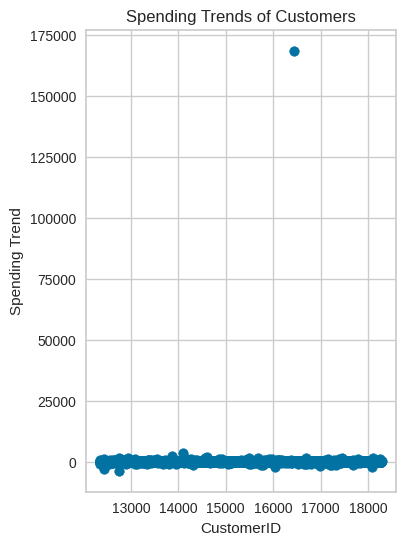

```python
plt.figure(figsize=(4,6))
plt.scatter(spending_trends['CustomerID'], spending_trends['Spending_Trend'])
plt.xlabel('CustomerID')
plt.ylabel('Spending Trend')
plt.title('Spending Trends of Customers')
plt.grid(True)
plt.show()
```

```python
# Merge the new features into the customer_data dataframe
customer_data = pd.merge(customer_data, seasonal_buying_patterns, on='CustomerID')
customer_data = pd.merge(customer_data, spending_trends, on='CustomerID')

# Display the first few rows of the customer_data dataframe
customer_data.head()
```

|  | CustomerID | Days_Since_Last_Purchase | Total_Transactions | Total_Products_Purchased | Total_Spend | Average_Transaction_Value | Unique_Products_Purchased | Average_Days_Between_Purchases | Day_Of_Week | Hour | Is_UK | Cancellation_Frequency | Cancellation_Rate | Monthly_Spending_Mean | Monthly_Spending_Std | Spending_Trend |
| --- | --- | --- | --- | --- | --- | --- | --- | --- | --- | --- | --- | --- | --- | --- | --- | --- |
| 0 | 12347.0 | 2 | 7 | 2458 | 4310.00 | 615.714286 | 103 | 2.016575 | 1 | 14 | 0 | 0.0 | 0.0 | 615.714286 | 341.070789 | 4.486071 |
| 1 | 12348.0 | 75 | 4 | 2341 | 1797.24 | 449.310000 | 22 | 9.433333 | 3 | 19 | 0 | 0.0 | 0.0 | 449.310000 | 301.159918 | -160.884000 |
| 2 | 12349.0 | 18 | 1 | 631 | 1757.55 | 1757.550000 | 73 | 0.000000 | 0 | 9 | 0 | 0.0 | 0.0 | 1757.550000 | 0.000000 | 0.000000 |
| 3 | 12350.0 | 310 | 1 | 197 | 334.40 | 334.400000 | 17 | 0.000000 | 2 | 16 | 0 | 0.0 | 0.0 | 334.400000 | 0.000000 | 0.000000 |
| 4 | 12352.0 | 36 | 8 | 536 | 2506.04 | 313.255000 | 59 | 3.095238 | 1 | 14 | 0 | 3.0 | 3.0 | 626.510000 | 453.171921 | -58.712000 |

```python
customer_data['CustomerID'] = customer_data['CustomerID'].astype(str)

customer_data = customer_data.convert_dtypes()
```

```python
customer_data.head()
```

|  | CustomerID | Days_Since_Last_Purchase | Total_Transactions | Total_Products_Purchased | Total_Spend | Average_Transaction_Value | Unique_Products_Purchased | Average_Days_Between_Purchases | Day_Of_Week | Hour | Is_UK | Cancellation_Frequency | Cancellation_Rate | Monthly_Spending_Mean | Monthly_Spending_Std | Spending_Trend |
| --- | --- | --- | --- | --- | --- | --- | --- | --- | --- | --- | --- | --- | --- | --- | --- | --- |
| 0 | 12347.0 | 2 | 7 | 2458 | 4310.0 | 615.714286 | 103 | 2.016575 | 1 | 14 | 0 | 0 | 0.0 | 615.714286 | 341.070789 | 4.486071 |
| 1 | 12348.0 | 75 | 4 | 2341 | 1797.24 | 449.31 | 22 | 9.433333 | 3 | 19 | 0 | 0 | 0.0 | 449.31 | 301.159918 | -160.884 |
| 2 | 12349.0 | 18 | 1 | 631 | 1757.55 | 1757.55 | 73 | 0.0 | 0 | 9 | 0 | 0 | 0.0 | 1757.55 | 0.0 | 0.0 |
| 3 | 12350.0 | 310 | 1 | 197 | 334.4 | 334.4 | 17 | 0.0 | 2 | 16 | 0 | 0 | 0.0 | 334.4 | 0.0 | 0.0 |
| 4 | 12352.0 | 36 | 8 | 536 | 2506.04 | 313.255 | 59 | 3.095238 | 1 | 14 | 0 | 3 | 3.0 | 626.51 | 453.171921 | -58.712 |

```python
customer_data.info()
```

```
<class 'pandas.core.frame.DataFrame'>
RangeIndex: 4267 entries, 0 to 4266
Data columns (total 16 columns):
 #   Column                          Non-Null Count  Dtype
---  ------                          --------------  -----
 0   CustomerID                      4267 non-null   string
 1   Days_Since_Last_Purchase        4267 non-null   Int64
 2   Total_Transactions              4267 non-null   Int64
 3   Total_Products_Purchased        4267 non-null   Int64
 4   Total_Spend                     4267 non-null   Float64
 5   Average_Transaction_Value       4267 non-null   Float64
 6   Unique_Products_Purchased       4267 non-null   Int64
 7   Average_Days_Between_Purchases  4267 non-null   Float64
 8   Day_Of_Week                     4267 non-null   Int32
 9   Hour                            4267 non-null   Int32
 10  Is_UK                           4267 non-null   Int64
 11  Cancellation_Frequency          4267 non-null   Int64
 12  Cancellation_Rate               4267 non-null   Float64
 13  Monthly_Spending_Mean           4267 non-null   Float64
 14  Monthly_Spending_Std            4267 non-null   Float64
 15  Spending_Trend                  4267 non-null   Float64
dtypes: Float64(7), Int32(2), Int64(6), string(1)
memory usage: 562.7 KB
```

```python
customer_data
```

|  | CustomerID | Days_Since_Last_Purchase | Total_Transactions | Total_Products_Purchased | Total_Spend | Average_Transaction_Value | Unique_Products_Purchased | Average_Days_Between_Purchases | Day_Of_Week | Hour | Is_UK | Cancellation_Frequency | Cancellation_Rate | Monthly_Spending_Mean | Monthly_Spending_Std | Spending_Trend |
| --- | --- | --- | --- | --- | --- | --- | --- | --- | --- | --- | --- | --- | --- | --- | --- | --- |
| 0 | 12347.0 | 2 | 7 | 2458 | 4310.0 | 615.714286 | 103 | 2.016575 | 1 | 14 | 0 | 0 | 0.0 | 615.714286 | 341.070789 | 4.486071 |
| 1 | 12348.0 | 75 | 4 | 2341 | 1797.24 | 449.31 | 22 | 9.433333 | 3 | 19 | 0 | 0 | 0.0 | 449.31 | 301.159918 | -160.884 |
| 2 | 12349.0 | 18 | 1 | 631 | 1757.55 | 1757.55 | 73 | 0.0 | 0 | 9 | 0 | 0 | 0.0 | 1757.55 | 0.0 | 0.0 |
| 3 | 12350.0 | 310 | 1 | 197 | 334.4 | 334.4 | 17 | 0.0 | 2 | 16 | 0 | 0 | 0.0 | 334.4 | 0.0 | 0.0 |
| 4 | 12352.0 | 36 | 8 | 536 | 2506.04 | 313.255 | 59 | 3.095238 | 1 | 14 | 0 | 3 | 3.0 | 626.51 | 453.171921 | -58.712 |
| ... | ... | ... | ... | ... | ... | ... | ... | ... | ... | ... | ... | ... | ... | ... | ... | ... |
| 4262 | 18280.0 | 277 | 1 | 45 | 180.6 | 180.6 | 10 | 0.0 | 0 | 9 | 1 | 0 | 0.0 | 180.6 | 0.0 | 0.0 |
| 4263 | 18281.0 | 180 | 1 | 54 | 80.82 | 80.82 | 7 | 0.0 | 6 | 10 | 1 | 0 | 0.0 | 80.82 | 0.0 | 0.0 |
| 4264 | 18282.0 | 7 | 2 | 103 | 178.05 | 89.025 | 12 | 10.818182 | 4 | 13 | 1 | 1 | 0.333333 | 89.025 | 15.817979 | -22.37 |
| 4265 | 18283.0 | 3 | 16 | 1357 | 2045.53 | 127.845625 | 263 | 0.463889 | 3 | 14 | 1 | 0 | 0.0 | 204.553 | 165.490044 | 22.332909 |
| 4266 | 18287.0 | 42 | 3 | 1586 | 1837.28 | 612.426667 | 59 | 2.304348 | 2 | 10 | 1 | 0 | 0.0 | 918.64 | 216.883792 | 306.72 |

4267 rows × 16 columns

```python
customer_data.columns
```

```
Index(['CustomerID', 'Days_Since_Last_Purchase', 'Total_Transactions',
       'Total_Products_Purchased', 'Total_Spend', 'Average_Transaction_Value',
       'Unique_Products_Purchased', 'Average_Days_Between_Purchases',
       'Day_Of_Week', 'Hour', 'Is_UK', 'Cancellation_Frequency',
       'Cancellation_Rate', 'Monthly_Spending_Mean', 'Monthly_Spending_Std',
       'Spending_Trend'],
      dtype='object')
```

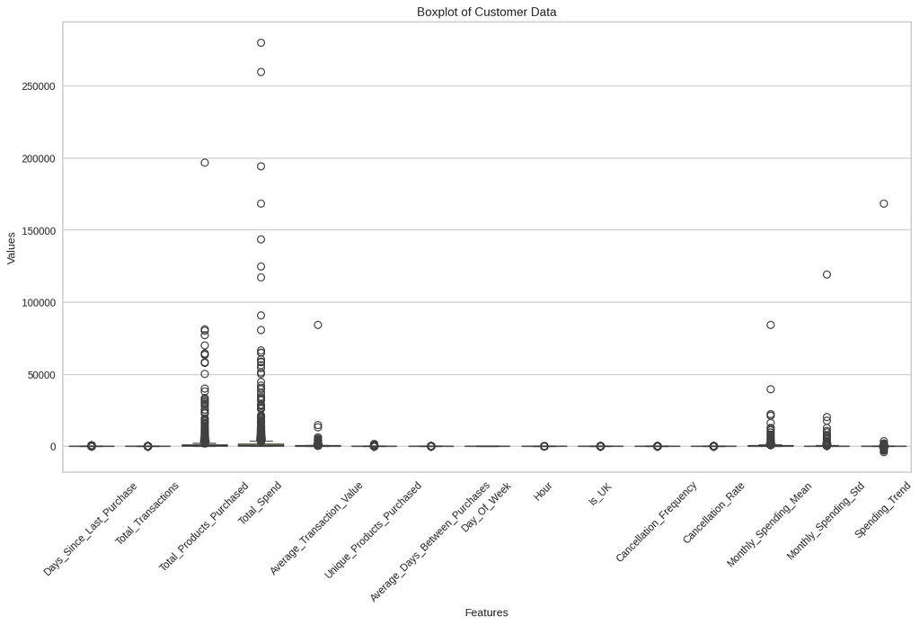

```python
# Define the columns to plot
columns_to_plot = ['CustomerID','Days_Since_Last_Purchase', 'Total_Transactions',
                   'Total_Products_Purchased', 'Total_Spend', 'Average_Transaction_Value',
                   'Unique_Products_Purchased', 'Average_Days_Between_Purchases',
                   'Day_Of_Week', 'Hour', 'Is_UK', 'Cancellation_Frequency',
                   'Cancellation_Rate', 'Monthly_Spending_Mean', 'Monthly_Spending_Std',
                   'Spending_Trend']

# Create boxplot using seaborn
plt.figure(figsize=(15, 8))
sns.boxplot(data=customer_data[columns_to_plot])
plt.xticks(rotation=45)  # Rotate x-axis labels for better readability
plt.title('Boxplot of Customer Data')
plt.xlabel('Features')
plt.ylabel('Values')
plt.show()
```

```python
# Initializing the IsolationForest model with a contamination parameter of 0.05
model = IsolationForest(contamination=0.05, random_state=0)

# Fitting the model on our dataset (converting DataFrame to NumPy to avoid warning)
customer_data['Outlier_Scores'] = model.fit_predict(customer_data.iloc[:, 1:].to_numpy())

# Creating a new column to identify outliers (1 for inliers and -1 for outliers)
customer_data['Is_Outlier'] = [1 if x == -1 else 0 for x in customer_data['Outlier_Scores']]

# Display the first few rows of the customer_data dataframe
customer_data.head()
```

|  | CustomerID | Days_Since_Last_Purchase | Total_Transactions | Total_Products_Purchased | Total_Spend | Average_Transaction_Value | Unique_Products_Purchased | Average_Days_Between_Purchases | Day_Of_Week | Hour | Is_UK | Cancellation_Frequency | Cancellation_Rate | Monthly_Spending_Mean | Monthly_Spending_Std | Spending_Trend | Outlier_Scores | Is_Outlier |
| --- | --- | --- | --- | --- | --- | --- | --- | --- | --- | --- | --- | --- | --- | --- | --- | --- | --- | --- |
| 0 | 12347.0 | 2 | 7 | 2458 | 4310.0 | 615.714286 | 103 | 2.016575 | 1 | 14 | 0 | 0 | 0.0 | 615.714286 | 341.070789 | 4.486071 | 1 | 0 |
| 1 | 12348.0 | 75 | 4 | 2341 | 1797.24 | 449.31 | 22 | 9.433333 | 3 | 19 | 0 | 0 | 0.0 | 449.31 | 301.159918 | -160.884 | 1 | 0 |
| 2 | 12349.0 | 18 | 1 | 631 | 1757.55 | 1757.55 | 73 | 0.0 | 0 | 9 | 0 | 0 | 0.0 | 1757.55 | 0.0 | 0.0 | 1 | 0 |
| 3 | 12350.0 | 310 | 1 | 197 | 334.4 | 334.4 | 17 | 0.0 | 2 | 16 | 0 | 0 | 0.0 | 334.4 | 0.0 | 0.0 | 1 | 0 |
| 4 | 12352.0 | 36 | 8 | 536 | 2506.04 | 313.255 | 59 | 3.095238 | 1 | 14 | 0 | 3 | 3.0 | 626.51 | 453.171921 | -58.712 | 1 | 0 |

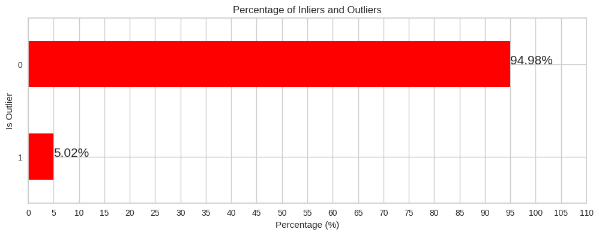

```python
# Calculate the percentage of inliers and outliers
outlier_percentage = customer_data['Is_Outlier'].value_counts(normalize=True) * 100

# Plotting the percentage of inliers and outliers
plt.figure(figsize=(12, 4))
outlier_percentage.plot(kind='barh', color='red')

# Adding the percentage labels on the bars
for index, value in enumerate(outlier_percentage):
    plt.text(value, index, f'{value:.2f}%', fontsize=15)

plt.title('Percentage of Inliers and Outliers')
plt.xticks(ticks=np.arange(0, 115, 5))
plt.xlabel('Percentage (%)')
plt.ylabel('Is Outlier')
plt.gca().invert_yaxis()
plt.show()
```

```python
outliers_data = customer_data[customer_data['Is_Outlier'] == 1]
```

```python
# Remove the outliers from the main dataset
customer_data = customer_data[customer_data['Is_Outlier'] == 0]

# Drop the 'Outlier_Scores' and 'Is_Outlier' columns
customer_data = customer_data.drop(columns=['Outlier_Scores', 'Is_Outlier'])

# Reset the index of the cleaned data
customer_data.reset_index(drop=True, inplace=True)
```

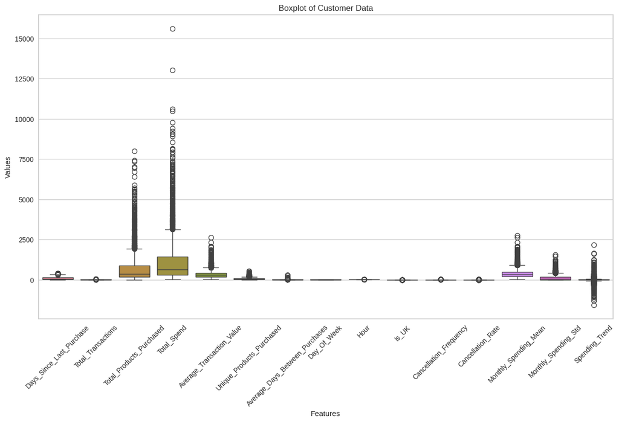

```python
plt.figure(figsize=(15, 8))
sns.boxplot(data=customer_data[columns_to_plot])
plt.xticks(rotation=45)  # Rotate x-axis labels for better readability
plt.title('Boxplot of Customer Data')
plt.xlabel('Features')
plt.ylabel('Values')
plt.show()
```

```python
# Initialize the StandardScaler
scaler = StandardScaler()
```

```python
columns_to_exclude = ['CustomerID', 'Is_UK', 'Day_Of_Week','InvoiceDay']

columns_to_scale = customer_data.columns.difference(columns_to_exclude)

# Copy the cleaned dataset
customer_data_scaled = customer_data.copy()

customer_data_scaled[columns_to_scale] = scaler.fit_transform(customer_data_scaled[columns_to_scale])

customer_data_scaled.head()
```

|  | CustomerID | Days_Since_Last_Purchase | Total_Transactions | Total_Products_Purchased | Total_Spend | Average_Transaction_Value | Unique_Products_Purchased | Average_Days_Between_Purchases | Day_Of_Week | Hour | Is_UK | Cancellation_Frequency | Cancellation_Rate | Monthly_Spending_Mean | Monthly_Spending_Std | Spending_Trend |
| --- | --- | --- | --- | --- | --- | --- | --- | --- | --- | --- | --- | --- | --- | --- | --- | --- |
| 0 | 12347.0 | -0.916953 | 0.985939 | 2.084423 | 2.331351 | 1.160988 | 0.793004 | -0.119570 | 1 | 0.640791 | 0 | -0.528259 | -0.430492 | 0.830244 | 1.435855 | 0.056170 |
| 1 | 12348.0 | -0.179097 | 0.147556 | 1.947311 | 0.482689 | 0.478127 | -0.555519 | 0.630612 | 3 | 2.803261 | 0 | -0.528259 | -0.430492 | 0.238267 | 1.187797 | -0.930713 |
| 2 | 12349.0 | -0.755231 | -0.690826 | -0.056626 | 0.453488 | 5.846659 | 0.293551 | -0.323540 | 0 | -1.521679 | 0 | -0.528259 | -0.430492 | 4.892277 | -0.684000 | 0.029398 |
| 3 | 12350.0 | 2.196194 | -0.690826 | -0.565228 | -0.593537 | 0.006578 | -0.638761 | -0.323540 | 2 | 1.505779 | 0 | -0.528259 | -0.430492 | -0.170520 | -0.684000 | 0.029398 |
| 4 | 12352.0 | -0.573294 | 1.265400 | -0.167956 | 1.004160 | -0.080193 | 0.060473 | -0.010466 | 1 | 0.640791 | 0 | 2.097704 | 3.655631 | 0.868649 | 2.132596 | -0.320979 |

```python
customer_data_scaled.set_index('CustomerID', inplace=True)
```

```python
# Apply PCA
pca = PCA().fit(customer_data_scaled)
```

```python
# Calculate the Cumulative Sum of the Explained Variance
explained_variance_ratio = pca.explained_variance_ratio_
cumulative_explained_variance = np.cumsum(explained_variance_ratio)
```

```python
explained_variance_ratio
```

```
array([0.28493638, 0.21024439, 0.1087452 , 0.07369957, 0.06705072,
       0.06062661, 0.05468438, 0.04419945, 0.03084781, 0.02684924,
       0.01340214, 0.012057  , 0.00471959, 0.00436329, 0.00357422])
```

```python
cumulative_explained_variance
```

```
array([0.28493638, 0.49518078, 0.60392598, 0.67762555, 0.74467627,
       0.80530288, 0.85998726, 0.90418671, 0.93503452, 0.96188376,
       0.9752859 , 0.9873429 , 0.99206249, 0.99642578, 1.        ])
```

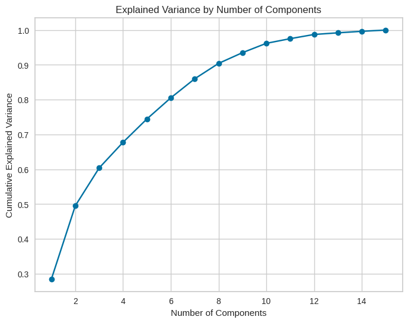

```python
plt.figure(figsize=(8,6))
plt.plot(np.arange(1, len(cumulative_explained_variance) + 1), cumulative_explained_variance, marker='o')
plt.xlabel('Number of Components')
plt.ylabel('Cumulative Explained Variance')
plt.title('Explained Variance by Number of Components')
plt.show()
```

```python
desired_variance_explained = 0.80

# Find the smallest k where the cumulative explained variance exceeds the threshold
optimal_k = np.argmax(cumulative_explained_variance >= desired_variance_explained) + 1
print("Optimal k to retain", desired_variance_explained, "of the variance:", optimal_k)
```

```
Optimal k to retain 0.8 of the variance: 6
```

```python
# Set the optimal k value (based on our analysis, we can choose 6)
optimal_k = 6
```

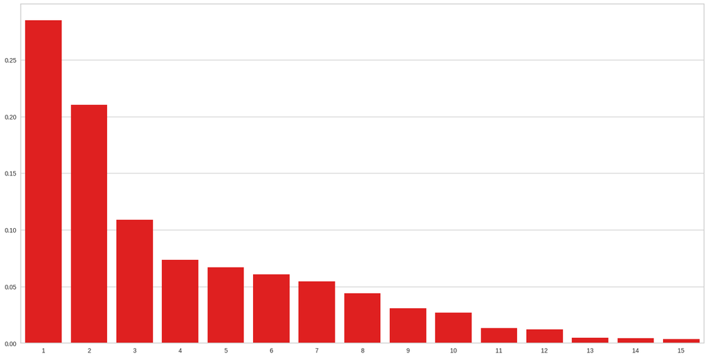

```python
# Plot the cumulative explained variance against the number of components
plt.figure(figsize=(20, 10))

# Bar chart for the explained variance of each component
barplot = sns.barplot(x=list(range(1, len(cumulative_explained_variance) + 1)),y=explained_variance_ratio,color='red',)
```

```python
# Creating a PCA object with 6 components
pca = PCA(n_components=6)

customer_data_pca = pca.fit_transform(customer_data_scaled)

column_names = []

for i in range(pca.n_components_):

    column_names.append('PC' + str(i + 1))


customer_data_pca = pd.DataFrame(customer_data_pca, columns=column_names)


customer_data_pca.index = customer_data_scaled.index
```

```python
customer_data_pca.head()
```

| CustomerID | PC1 | PC2 | PC3 | PC4 | PC5 | PC6 |
| --- | --- | --- | --- | --- | --- | --- |
| 12347.0 | 3.417742 | -1.347816 | 1.134397 | 1.708350 | -0.570142 | -0.038815 |
| 12348.0 | 1.130880 | 0.591307 | 0.660540 | 1.246546 | -1.148740 | -0.750812 |
| 12349.0 | 2.548642 | -2.851382 | 6.453147 | -1.320732 | 1.335417 | 0.031448 |
| 12350.0 | -1.913125 | -0.590857 | 0.763310 | -0.760160 | -1.298112 | 0.099241 |
| 12352.0 | 3.377813 | -1.536748 | -1.797159 | -2.259588 | -0.123092 | -0.290063 |

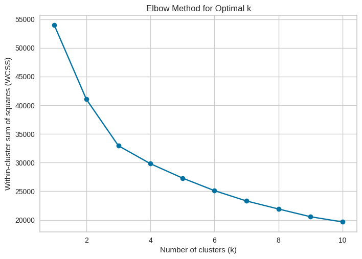

```python
wcss = []


for k in range(1, 11):


    kmeans = KMeans(n_clusters=k, random_state=0)
    kmeans.fit(customer_data_pca)

    wcss.append(kmeans.inertia_)

# Plot the WCSS values against the range of k values
plt.plot(range(1, 11), wcss, marker='o')
plt.xlabel('Number of clusters (k)')
plt.ylabel('Within-cluster sum of squares (WCSS)')
plt.title('Elbow Method for Optimal k')
plt.show()
```

```python
def kmeans_clustering(df, k):

    kmeans = KMeans(n_clusters=k, random_state=0)


    cluster_labels = kmeans.fit_predict(df)

    # Compute silhouette score
    silhouette_avg = silhouette_score(df, cluster_labels)

    # Compute Davies-Bouldin score
    db_score = davies_bouldin_score(df, cluster_labels)

    # Compute Calinski-Harabasz score
    ch_score = calinski_harabasz_score(df, cluster_labels)


    inertia = kmeans.inertia_

    return cluster_labels, silhouette_avg, db_score, ch_score, inertia

cluster_labels, silhouette_avg, db_score, ch_score, inertia = kmeans_clustering(customer_data_pca, 3)


print("Performance measures for k=3:")
print("Silhouette Score:", silhouette_avg)
print("Davies-Bouldin Score:", db_score)
print("Calinski-Harabasz Score:", ch_score)
print("Inertia:", inertia)
```

```
Performance measures for k=3:
Silhouette Score: 0.23812055390790537
Davies-Bouldin Score: 1.3349712826577012
Calinski-Harabasz Score: 1291.0680582888208
Inertia: 32937.29881119738
```

```python
customer_data_pca
```

| CustomerID | PC1 | PC2 | PC3 | PC4 | PC5 | PC6 |
| --- | --- | --- | --- | --- | --- | --- |
| 12347.0 | 3.417742 | -1.347816 | 1.134397 | 1.708350 | -0.570142 | -0.038815 |
| 12348.0 | 1.130880 | 0.591307 | 0.660540 | 1.246546 | -1.148740 | -0.750812 |
| 12349.0 | 2.548642 | -2.851382 | 6.453147 | -1.320732 | 1.335417 | 0.031448 |
| 12350.0 | -1.913125 | -0.590857 | 0.763310 | -0.760160 | -1.298112 | 0.099241 |
| 12352.0 | 3.377813 | -1.536748 | -1.797159 | -2.259588 | -0.123092 | -0.290063 |
| ... | ... | ... | ... | ... | ... | ... |
| 18280.0 | -2.172625 | -2.711335 | 0.043561 | -0.626442 | 0.541752 | -0.144511 |
| 18281.0 | -2.436713 | 3.301309 | -0.398936 | -0.434406 | 0.756074 | -0.033821 |
| 18282.0 | -1.464864 | 1.369006 | -1.395387 | 0.167291 | 0.536373 | 0.056979 |
| 18283.0 | 2.622515 | 0.936406 | -1.801709 | 2.695553 | -1.735184 | 0.053734 |
| 18287.0 | 1.586834 | -0.625664 | 2.096526 | 0.400656 | 0.888309 | 1.714594 |

4053 rows × 6 columns

```python
customer_data_reset_index = customer_data.reset_index()

# Perform K-means clustering for k=3
kmeans = KMeans(n_clusters=3, random_state=0)
cluster_labels = kmeans.fit_predict(customer_data_pca)

customer_data_pca_with_labels = customer_data_pca.copy()
customer_data_pca_with_labels['Cluster'] = cluster_labels

final_data = pd.merge(customer_data_reset_index, customer_data_pca_with_labels['Cluster'], on='CustomerID')
```

```python
final_data.head(3)
```

|  | index | CustomerID | Days_Since_Last_Purchase | Total_Transactions | Total_Products_Purchased | Total_Spend | Average_Transaction_Value | Unique_Products_Purchased | Average_Days_Between_Purchases | Day_Of_Week | Hour | Is_UK | Cancellation_Frequency | Cancellation_Rate | Monthly_Spending_Mean | Monthly_Spending_Std | Spending_Trend | Cluster |
| --- | --- | --- | --- | --- | --- | --- | --- | --- | --- | --- | --- | --- | --- | --- | --- | --- | --- | --- |
| 0 | 0 | 12347.0 | 2 | 7 | 2458 | 4310.0 | 615.714286 | 103 | 2.016575 | 1 | 14 | 0 | 0 | 0.0 | 615.714286 | 341.070789 | 4.486071 | 0 |
| 1 | 1 | 12348.0 | 75 | 4 | 2341 | 1797.24 | 449.31 | 22 | 9.433333 | 3 | 19 | 0 | 0 | 0.0 | 449.31 | 301.159918 | -160.884 | 2 |
| 2 | 2 | 12349.0 | 18 | 1 | 631 | 1757.55 | 1757.55 | 73 | 0.0 | 0 | 9 | 0 | 0 | 0.0 | 1757.55 | 0.0 | 0.0 | 0 |

```python
final_data.columns
```

```
Index(['index', 'CustomerID', 'Days_Since_Last_Purchase', 'Total_Transactions',
       'Total_Products_Purchased', 'Total_Spend', 'Average_Transaction_Value',
       'Unique_Products_Purchased', 'Average_Days_Between_Purchases',
       'Day_Of_Week', 'Hour', 'Is_UK', 'Cancellation_Frequency',
       'Cancellation_Rate', 'Monthly_Spending_Mean', 'Monthly_Spending_Std',
       'Spending_Trend', 'Cluster'],
      dtype='object')
```

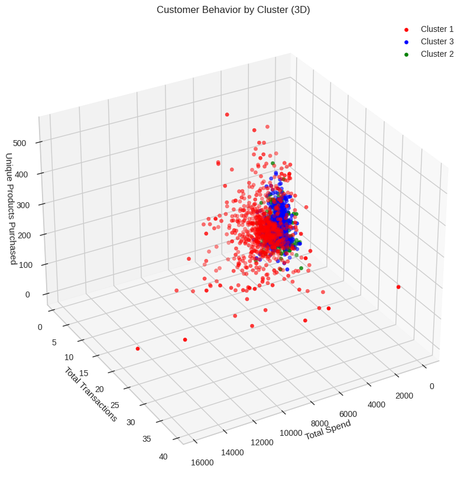

```python
# 3D scatter plot (Total_Spend, Total_Transactions, Unique_Products_Purchased)
fig = plt.figure(figsize=(10, 10))
ax = fig.add_subplot(111, projection='3d')
ax.grid(True)
ax.view_init(30, 60)


colors = ['red', 'green', 'blue']
for cluster in final_data['Cluster'].unique():
    selection = final_data[final_data['Cluster'] == cluster]
    ax.scatter(selection['Total_Spend'], selection['Total_Transactions'], selection['Unique_Products_Purchased'], c=colors[cluster], label=f'Cluster {cluster+1}')

ax.set_xlabel('Total Spend')
ax.set_ylabel('Total Transactions')
ax.set_zlabel('Unique Products Purchased')
ax.legend()
plt.title('Customer Behavior by Cluster (3D)')
plt.show()
```